# BAE 590 Final Project: Analysis of Dissolved Oxygen levels in Wake County Water Resources

Sakshi Sakshi

Fall 2020

## Background

This project focuses on determining the changes in the trends of Dissolved Oxygen Levels, in water bodies across Wake County. This data has been downloaded from the National Water Quality Monitoring Council (NWQMC). The original dataset has 63 columns and 386794 observations. I decided to focus on just the dissolved oxygen levels.In this analysis, I have performed changepoint analysis, to **determine how the oxygen levels have changed over the years**.

The dissolved oxygen is an important factor to determine the quality of water. As the dissolved oxygen decreases, the water becomes inhabitable for aquatic life. This could be a result of excess algal bloom, on whose decomposition, the bacteria consume a lot of oxygen, resulting in a reduction in levels of oxygen. The excess algal bloom is a result of excessive use of fertilizers in the crops. Hence, monitoring the oxygen levels is advised to ensure the health of aquatic life is also good.

The dissolved oxygen is also more in colder temperatures, and reduces as the temperature of water increases. On the other hand, if the concentration of oxygen is more in water, there is lesser concentrations of other minerals, which could be required.

## Dataset Description

I selected the following columns to perform the analysis (the column names have been ‘cleaned up’ by the package janitor):

- activity_start_date
- activity_start_time_time
- characteristic_name
- result_measure_value
- result_measure_measure_unit_code

Characteristics and their corresponding Units of Measurement

| Characteristics | Unit of Measurement |
| --- | --- |
| Temperature, water | deg C |
| Barometric pressure | mm/Hg |
| Specific conductance | uS/cm @25C |
| Acidity, hydrogen ion (H+) | mg/l |
| Oxygen | mg/l |
| Oxygen | % saturatn |
| pH | std units |
| Nitrogen, mixed forms (NH3), (NH4), organic, (NO2) and (NO3) | NA |
| Organic Nitrogen | NA |
| Ammonia and ammonium | NA |

Change in temperature over the years, an example of the data recorded:

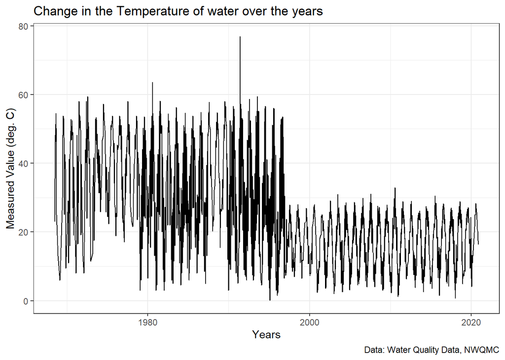

```r
library(tidyr)
library(tidyverse)
library(lubridate)
library(janitor)

# reading the data
wake_data <- read_csv("data/result.csv") %>% clean_names()

# selecting the relevant columns and removing NAs
wake_mod <- wake_data %>%
  select(activity_start_date, activity_start_time_time,
         characteristic_name, result_measure_value,
         result_measure_measure_unit_code) %>%
  na.omit()

# filtering out temperature data
wake_temp <- wake_mod %>%
  filter(characteristic_name == 'Temperature, water') %>%
  group_by(activity_start_date) %>%
  summarise(activity_start_date, result_measure_value = mean(result_measure_value))

wake_temp %>%
  ggplot(mapping = aes(activity_start_date, result_measure_value)) +
  geom_line() +
  theme_bw() +
  labs(title = "Change in the Temperature of water over the years",
       caption = "Data: Water Quality Data, NWQMC") +
  scale_y_continuous("Measured Value (deg. C)") +
  scale_x_date("Years")
```

## Methods

### 1. **Data tidying and wrangling**:

The input data files have been formatted to incorporate the relevant data. The first task was to select the relevant columns as given above. The second task was to filter out the relevant data for this analysis. Out of 63 columns, I selected 5 relevant columns. Then, I filtered out the data for the characteristic ‘Oxygen’ with unit ‘mg/l’.

The data had observations taken at different times of a day. I have averaged out the observations, to display the data for each day. The data is henceforth, converted to a daily time- series data. The function group_by() is used to aggregate data, and summarise() is used to take the average of daily observations.

The following code has been used to wrangle the data:

```r
library(tidyr)
library(tidyverse)
library(lubridate)
library(janitor)

# reading the data
wake_data <- read_csv("data/result.csv") %>% clean_names()

# selecting the relevant columns and removing NAs
wake_mod <- wake_data %>%
  select(activity_start_date, activity_start_time_time,
         characteristic_name, result_measure_value,
         result_measure_measure_unit_code) %>%
  na.omit()

# filtering out the Oxygen measurements in mg/l
wake_oxy <- wake_mod %>%
  filter(characteristic_name == 'Oxygen' & result_measure_measure_unit_code == 'mg/l') %>%
  group_by(activity_start_date) %>%
  summarise(activity_start_date, result_measure_value = mean(result_measure_value))
```

### 2. **Statistical Analysis**:

I performed change detection analysis for the given data. Change detection or change point detection tries to identify the times when the probability distribution of time series changes. This analysis determines whether and when the behavior of series changes significantly.

I have used the ‘changepoint’ library to conduct the analysis. At first, I observed the time series visualization as given below:

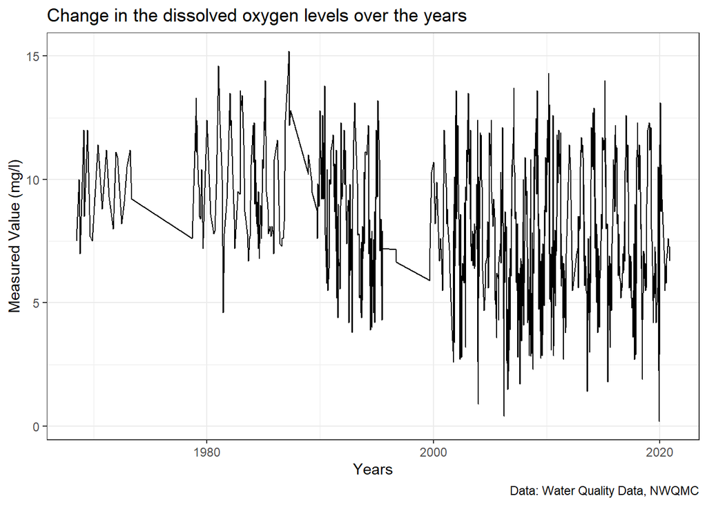

```r
library(ggplot2)

# plotting
wake_oxy %>%
  ggplot(mapping = aes(activity_start_date, result_measure_value)) +
  theme_bw() +
  geom_line() +
  labs(title = "Change in the dissolved oxygen levels over the years",
       caption = "Data: Water Quality Data, NWQMC") +
  scale_y_continuous("Measured Value (mg/l)") +
  scale_x_date("Years")
```

## Code and analysis for Change point detection

#### The following code has been used to plot and perform changepoint analysis on the given data

```r
library(changepoint)

# change point analysis
# a Looking for one change point using the "AMOC" method
oxy_n.amoc <- cpt.mean(wake_oxy$result_measure_value, method = "AMOC")
cpts(oxy_n.amoc)  # change points
```

```
## [1] 242
```

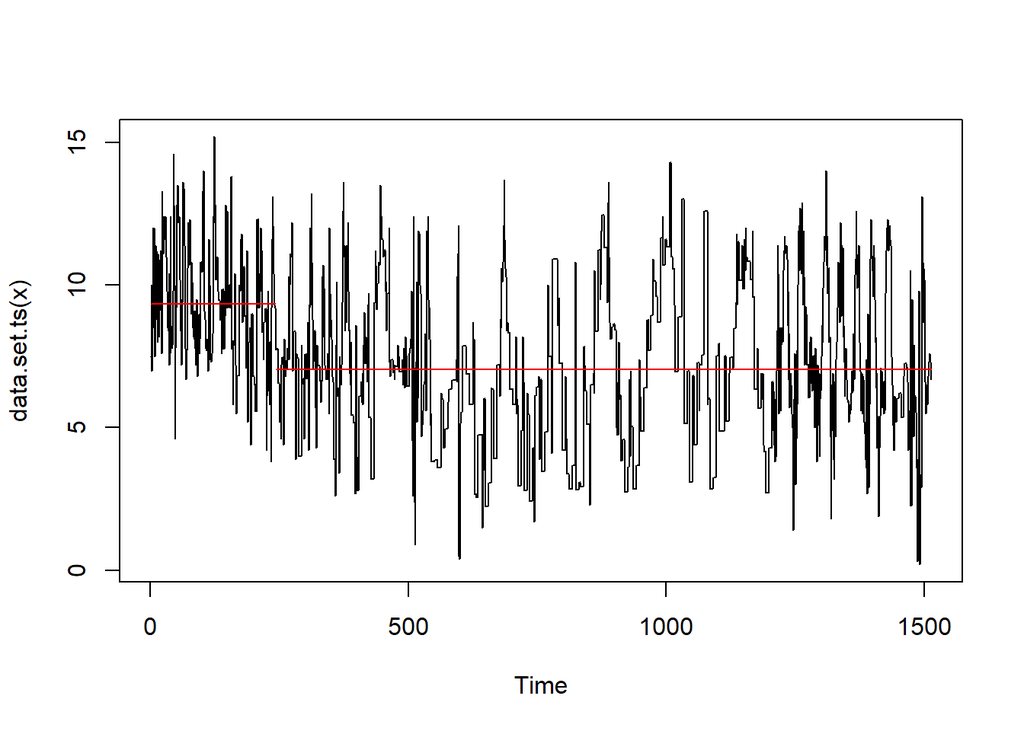

```r
oxy.cusum <- cpt.mean(wake_oxy$result_measure_value, pen.value = 1,
                      penalty = "Manual", test.stat = 'CUSUM')
plot(oxy_n.amoc) # visualization of the data
```

```r
# exact date for the changepoint
wake_oxy$activity_start_date[cpts(oxy_n.amoc)]
```

```
## [1] "1993-04-29"
```

From the above plot, we can observe that there has been a decrease in the dissolved oxygen level.

```r
# b Looking at the changes in the variance
oxy_v.man <- cpt.var(wake_oxy$result_measure_value, method = 'PELT',
                     penalty = 'Manual', pen.value = '2*log(n)')
cpts(oxy_v.man) # change points
```

```
##  [1]  157  427  465  469  505  604  618  771  777  792  798 1064 1072 1096 1100
## [16] 1122 1128 1460 1467 1506
```

```r
param.est(oxy_v.man) # estimated change points
```

```
## $variance
##  [1]  3.94772628  4.90871879  8.63366113  0.00000000  0.27833951  6.61844557
##  [7]  0.25000000  5.77798875  0.00000000  3.01484444  0.00000000  9.74924306
## [13]  0.03062500 16.87928819  0.00000000  1.35334298  0.00000000  7.00620304
## [19]  0.00522449  9.15575279  0.08816327
##
## $mean
## [1] 7.407006
```

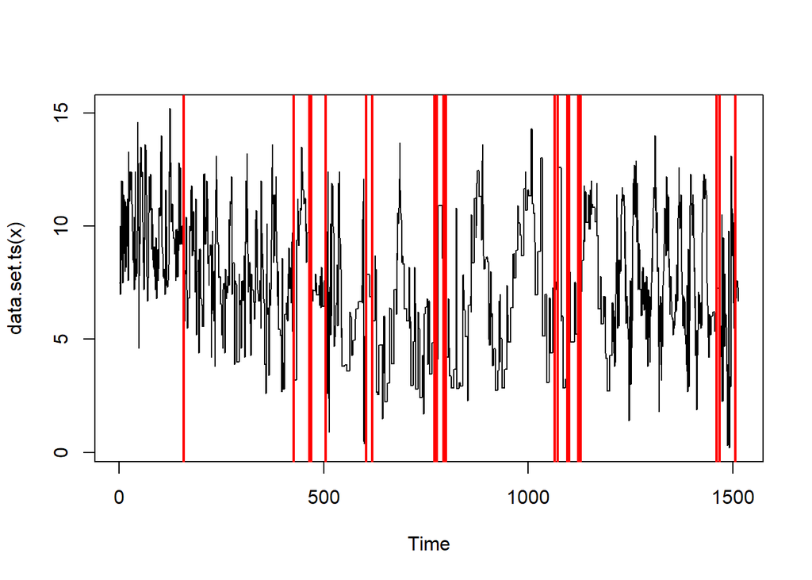

```r
plot(oxy_v.man, cpt.width=2) # visualization of change points
```

```r
wake_oxy$activity_start_date[cpts(oxy_v.man)] # exact dates of the change points
```

```
##  [1] "1990-05-22" "2002-11-13" "2003-05-08" "2003-05-12" "2003-10-17"
##  [6] "2006-04-04" "2006-04-06" "2007-12-11" "2007-12-12" "2008-04-08"
## [11] "2008-04-09" "2010-06-15" "2010-08-02" "2010-08-12" "2010-09-20"
## [16] "2010-10-26" "2010-11-08" "2019-07-24" "2019-08-06" "2020-07-21"
```

The points above depict the changes in the variance of the data. There are a lot of change points observed in the variance of the data.

```r
# c Changes in mean and variance
oxy_mv.binseg <- cpt.meanvar(wake_oxy$result_measure_value, test.stat = "Exponential",
                             method = 'BinSeg', Q=20, penalty = "SIC")
cpts(oxy_mv.binseg) # change points
```

```
## [1] 242
```

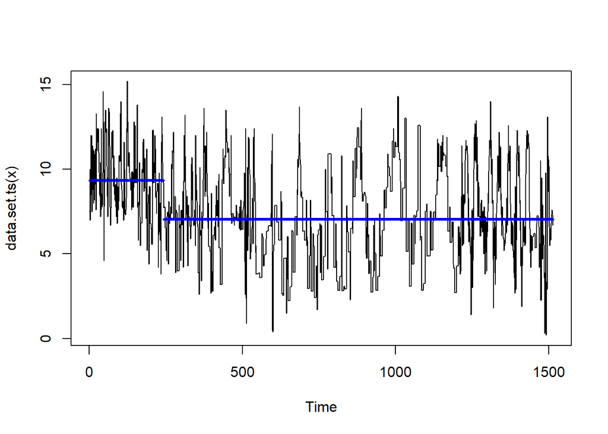

```r
plot(oxy_mv.binseg, cpt.width=3, cpt.col='blue') # visualizations
```

```r
wake_oxy$activity_start_date[cpts(oxy_mv.binseg)] # date of changepoint occurance
```

```
## [1] "1993-04-29"
```

From the above plot, we can observe that there has been a decrease in the dissolved oxygen level.

Lets observe the dissolved oxygen levels averaged over the years:

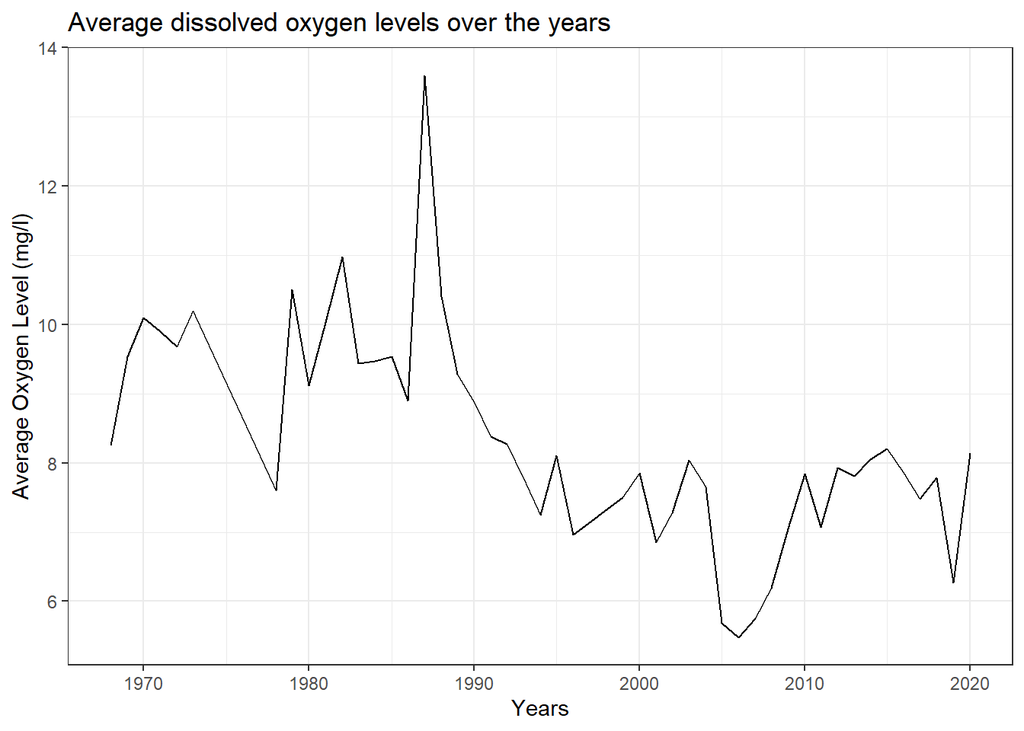

```r
yearly_oxy <- wake_mod %>%
  filter(characteristic_name == 'Oxygen' & result_measure_measure_unit_code == 'mg/l') %>%
  group_by(year(activity_start_date)) %>%
  summarise(result_measure_value = mean(result_measure_value))

# visualization
yearly_oxy %>%
  ggplot(mapping = aes(`year(activity_start_date)`, result_measure_value)) +
  geom_line() +
  theme_bw() +
  scale_y_continuous("Average Oxygen Level (mg/l)") +
  labs(x="Years",
       title = "Average dissolved oxygen levels over the years")
```

## Discussion

From the above graphs, we can see that the average levels of dissolved oxygen have reduced over the years. This could be a result of the increasing use of fertilizers over time. The nitrates in the fertilizers boost algal growth in water bodies, which in turn, reduces the dissolved oxygen level in the water. The Dissolved Oxygen levels below 3 mg/L are of concern and waters with levels below 1 mg/L are considered hypoxic and usually devoid of life.